# Análise de formas de adoçamento de sucos com aplicação de métodos não-paramétricos

## Introdução

Pode-se dizer, com segurança, que a maioria das pessoas que usam estatísticas está mais familiarizada com análises paramétricas do que com análises não-paramétricas. Estatística paramétrica é um ramo da estatística que presume que os dados são provenientes de um tipo de distribuição de probabilidade e faz inferências sobre os parâmetros da distribuição.

Os testes paramétricos visam analisar a variabilidade dos resultados da variável dependente, em função da manipulação das variáveis independentes, de forma a que se possa refutar (ou não) a hipótese nula, a qual postula que os resultados da investigação são devidos, não aos efeitos previstos pela hipótese experimental, mas a diferenças aleatórias nos resultados, devidas a outras variáveis irrelevantes ou ao acaso.

Geralmente, métodos paramétricos fazem mais suposições em comparação aos métodos da estatística não-paramétrica. Se essas suposições estiverem corretas, os métodos paramétricos poderão produzir estimativas mais precisas, possuindo maior potência estatística. Porém, se os dados não satisfazem as suposições feitas pelas técnicas tradicionais, métodos não-paramétricos de inferência estatística devem ser utilizados.

Alguns requisitos para utilização de testes paramétricos:

- Os resultados experimentais devem ser mensurados em escalas intervalares.
- Os resultados devem normalmente distribuídos, isto é, devem seguir a curva normal.
- deve haver homogeneidade da variância, isto é, a variabilidade dos resultados, para cada situação experimental, deve ser aproximadamente a mesma.
- Tamanho amostral suficiente.

A estatística não-paramétrica ou análise não-paramétrica é o termo utilizado para descrever um conjunto de técnicas utilizadas quando os métodos paramétricos não são os recomendados. As técnicas não-paramétricas assumem poucas ou nenhuma hipótese sobre a distribuição de probabilidade da população em estudo. Deste modo, traz uma vantagem na hora de realizar as análises adequadas de acordo com o objetivo do estudo. Portanto, os testes não paramétricos são conhecidos como testes livres de distribuição. Quando o estudo possui uma amostra muito pequena, dificilmente as suposições dos testes paramétricos serão atendidas, assim sendo recomendado o uso de algum método não-paramétrico.

Os testes não-paramétricos são utilizados para analisar uma amostra ou comparar duas ou mais. É também utilizado para amostras pareadas, assim como analisar correlação e métodos de reamostragem. Os principais testes não-paramétricos utilizados são: teste do Sinal (ou teste da Mediana), teste de Wilcoxon, teste de Mann-Whitney, teste de Kruskal Wallis e teste de Friedman. Esses são apenas alguns testes não-paramétricos utilizados, sendo que cada um possui suas respectivas suposições e serão utilizados em situações específicas.

Nesse texto os métodos serão utilizados para comparar formas de adoçamento de sucos em um estudo experimental

### Descrição do experimento

- Descrição

O experimento consiste na degustação de suco. 3 recipientes de suco de um mesmo fruto foram preparados e adocicados de 3 formas distrintas (acuçar,adoçante e sem açucar) sendo consumidos de forma intercalada e avaliados com notas que variam de 5 a 10 de acordo com o seu sabor por seus degustadores.

- Objetivo

Verificar se existe diferença entre a média das notas com relação a forma de adoçamento do suco e se constatada a diferença, identificar entre quais níveis do tratamento (categorias de adoçamento) as mesmas ocorrem.

- Metodologia
  - Delineamento de Blocos Casualizados
  - 10 Blocos (Pessoas) e 3 Tratamentos (formas de adoçamento)
- Variáveis
  - Degustador: representa a identificação de cada degustador (varia de 1 até 10)
  - Tratamento: representa as formas de adoçamento utilizadas (açucar,adoçante e natural)
  - Nota: representa as notas dadas a cada tipo de tratamento por cada degustador (varia de 5 até 10)

## Aplicação

### Carregando pacotes e dados utilizados

> **Pacotes utilizados**

```r
library(readr)
library(ggplot2)
library(dplyr)
library(tidyr)
library(rstatix)
library(PMCMRplus)
library(sysfonts)
library(extrafont)
library(showtext)
library(ez)

font_add_google('Roboto Slab','Roboto Slab')
showtext_auto()
```

> **Dados utilizados**

```r
Dataset <- readr::read_delim("df/Dataset.csv", ";",
                             col_types = cols(Degustador = col_factor(),
                                              Tratamento = col_factor(),
                                              Nota = col_number()),
                             locale = locale(encoding = "WINDOWS-1252"),
                             trim_ws = TRUE)
Dataset
```

| Degustador | Tratamento | Nota |
| --- | --- | --- |
| 1 | Açucar | 10 |
| 1 | Adoçante | 10 |
| 1 | Natural | 10 |
| 2 | Açucar | 10 |
| 2 | Adoçante | 9 |
| 2 | Natural | 8 |
| 3 | Açucar | 10 |
| 3 | Adoçante | 10 |
| 3 | Natural | 10 |
| 4 | Açucar | 10 |

[output cut: 20 more lines]

### Análise descritiva

> **Algumas medidas descritivas sumarizadas para cada um dos grupos**

```r
Dataset %>% group_by(Tratamento) %>%
  rstatix::get_summary_stats(Nota,
                             show = c("min","max","mean", "sd", "median", "iqr"))
```

| Tratamento | variable | n | min | max | mean | sd | median | iqr |
| --- | --- | --- | --- | --- | --- | --- | --- | --- |
| Açucar | Nota | 10 | 8 | 10 | 9.5 | 0.850 | 10.0 | 0.75 |
| Adoçante | Nota | 10 | 5 | 10 | 7.2 | 1.874 | 7.0 | 2.50 |
| Natural | Nota | 10 | 6 | 10 | 8.3 | 1.703 | 8.5 | 3.00 |

Com base nas medidas descritivas é possível afirmar que o suco adoçicado com açucar obteve maior média de avaliação e menor dispersão entre as notas recebidas.

> **Avaliação gráfica**

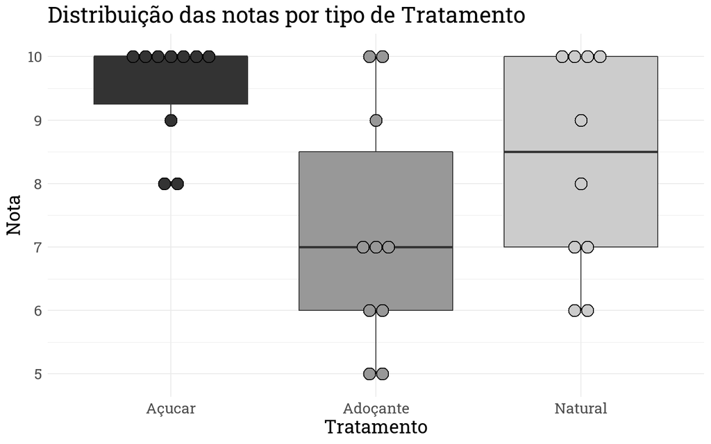

```r
Dataset %>%
  ggplot(aes(y=Nota,x=Tratamento,fill = Tratamento)) +
  geom_boxplot() +
  labs(title = "Distribuição das notas por tipo de Tratamento") +
  theme_minimal() +
  scale_fill_grey() +
  theme(legend.position="none",
        text = element_text(family='Roboto Slab',size = 30)) +
  geom_dotplot(binaxis='y', stackdir='center', dotsize=1,
               binwidth = 0.2)
```

Analisando o boxplot pode-se observar uma grande diferença entre a distribuição das notas, indicando possível violação do pressuposto de *esfericidade* e/ou *homocedasticidade*.

> **Identificação de pontos discrepantes (outliers) por tratamento**

```r
Dataset %>% group_by(Tratamento) %>% identify_outliers(Nota)
```

| Tratamento | Degustador | Nota | is.outlier | is.extreme |
| --- | --- | --- | --- | --- |
| Açucar | 8 | 8 | TRUE | FALSE |
| Açucar | 10 | 8 | TRUE | FALSE |

Foram identificados 2 outliers nas notas para o adoçamento açucar. Dado que os outliers não foram considerados extremos, os mesmos foram mantidos para análises subsequentes.

> **Avaliação do pressuposto de normalidade**

```r
Dataset  %>%
  group_by(Tratamento) %>%
  shapiro_test(Nota) %>%
  mutate(statistic = round(statistic,3),
         p = round(p,3)) %>%
  rename(Variável = variable,
         'P-Valor' = p)
```

| Tratamento | Variável | statistic | P-Valor |
| --- | --- | --- | --- |
| Açucar | Nota | 0.628 | 0.000 |
| Adoçante | Nota | 0.882 | 0.137 |
| Natural | Nota | 0.833 | 0.036 |

Com base no **p-valor** ($\alpha = 5\%$) é possível concluir que as notas dos grupos “açucar” e “natural” não são normalmente distribuidas.

> **Avaliação do pressuposto de homocedasticidade**

```r
# Modelo ANOVA para medidas repetidas (método paramétrico recomendado)
modelo <- ezANOVA(data = Dataset,        # dados utilizados
                  dv = Nota,             # variável dependente
                  wid = Degustador,      # variável identificadora (bloco)
                  within = Tratamento,   # variável preditora (tratamento)
                  detailed = TRUE,
                  type= 3,
                  return_aov = TRUE)

# Outra forma de Calcular:
  #* modelo <- aov(Nota ~ Tratamento + Degustador,data=Dataset)

# retendo os resíduos do modelo
res.modelo <- (proj(modelo$aov)[[3]][, "Residuals"])

# Teste de Bartlett
bartlett.test(res.modelo ~ Dataset$Tratamento)
```

```
##
##  Bartlett test of homogeneity of variances
##
## data:  res.modelo by Dataset$Tratamento
## Bartlett's K-squared = 2.6337, df = 2, p-value = 0.268
```

Com base no **p-valor** e considerando $\alpha$ = 5% não temos evidência para rejeitar a hipótese nula, ou seja, não houve violação do pressuposto de homocedasticidade.

> **Avaliação do pressuposto de esfericidade**

```r
modelo$`Mauchly's Test for Sphericity`
```

|  | Effect | W | p | p<.05 |
| --- | --- | --- | --- | --- |
| 2 | Tratamento | 0.5832933 | 0.1157572 |  |

Considerando um nível de significância de 5% não temos evidência para rejeitar a hipótese nula, ou seja, não houve violação do pressuposto de esfericidade.

Com base no delineamento do experimento (delineamento de blocos casualizados), tamanho amostral e resultados descritivos obtidos, o teste de Friedman foi escolhido para comparação dos grupos.

> **Teste de Friedman**

```r
Dataset %>% friedman_test(Nota ~ Tratamento | Degustador)
```

|  | .y. | n | statistic | df | p | method |
| --- | --- | --- | --- | --- | --- | --- |
| 1 | Nota | 10 | 10.41379 | 2 | 0.00547865 | Friedman test |

Considerando $\alpha$ = 5% temos evidência para rejeitar a hipótese nula, ou seja, existe diferença entre as formas de adoçamento com relação as notas recebidas (mediana e/ou distribuição das notas).

**PostHoc**

> **Dunn-Bonferroni**

```r
PMCMRplus::frdAllPairsSiegelTest(Dataset$Nota,
                                 Dataset$Tratamento,
                                 Dataset$Degustador,
                                 p.adjust = "bonferroni")
```

```
##
##  Pairwise comparisons using Siegel-Castellan all-pairs test for a two-way balanced complete block design
```

```
## data: y, groups and blocks
```

```
##          Açucar Adoçante
## Adoçante 0.03   -
## Natural  0.10   1.00
```

```
##
## P value adjustment method: bonferroni
```

> **Teste de Wilcox com correção de Bonferroni**

```r
Dataset %>% rstatix::wilcox_test(Nota ~ Tratamento,
                                 paired = TRUE,
                                 p.adjust.method = "bonferroni")
```

|  | .y. | group1 | group2 | n1 | n2 | statistic | p | p.adj | p.adj.signif |
| --- | --- | --- | --- | --- | --- | --- | --- | --- | --- |
| 1 | Nota | Açucar | Adoçante | 10 | 10 | 36 | 0.014 | 0.041 | * |
| 2 | Nota | Açucar | Natural | 10 | 10 | 21 | 0.031 | 0.093 | ns |
| 3 | Nota | Adoçante | Natural | 10 | 10 | 6 | 0.202 | 0.606 | ns |

Com um nível de significância de 5% é possível afirmar que as notas das formas de adoçamento ‘açucar’ e ‘adoçante’ diferem para ambos os métodos utilizados.

## Conclusão

- Com 95% de confiança é possível afirmar que houve diferença entre as formas de adoçamento de suco (mediana e/ou distribuição das notas das formas de adoçamento diferem).
- Pelos testes de Dunn-Bonferoni e Wilcox (com correção de bonferroni) considerando 95% de confiança as formas de adoçamento que diferiram foram “açucar” e “Adoçante”, logo ; $açucar^{a}$, $natural^{a,b}$ e $adoçante^{b}$.

## Referências

1. *estatística paramétrica* in Infopédia [em linha]. Porto: Porto Editora, 2003-2021. [consult. 2021-05-11 04:34:31]. Disponível na Internet: https://www.infopedia.pt/$estatistica-parametrica.
2. Rocha, K. R. da, & Bacelar Júnior, A. J. (2018). Anova Medidas Repetidas E Seus Pressupostos: Análise Passo a Passo De Um Experimento. *Revista Eletrônica Perspectivas Da Ciência e Tecnologia - ISSN: 1984-5693, 10, 29.* https://doi.org/10.22407/1984-5693.2018.v10.p.29-51.
3. *como escolher entre um teste nao parametrico e um teste parametrico*. Minitab, 2019. Disponível na internet: < https://blog.minitab.com/pt/como-escolher-entre-um-teste-nao-parametrico-e-um-teste-parametrico >